# PROJECT -----> RETAIL ANALYTICS

```python
import numpy as np
import pandas as pd
import matplotlib.pyplot as plt
import seaborn as sns
```

```python
df = pd.read_csv(r"C:\Users\LENOVO\Desktop\top mentor\Superstore.csv", encoding="latin1")
print(df)
```

```
      Row ID        Order ID  Order Date   Ship Date       Ship Mode  \
0          1  CA-2016-152156  08-11-2016  11-11-2016    Second Class
1          2  CA-2016-152156  08-11-2016  11-11-2016    Second Class
2          3  CA-2016-138688  12-06-2016  16-06-2016    Second Class
3          4  US-2015-108966  11-10-2015  18-10-2015  Standard Class
4          5  US-2015-108966  11-10-2015  18-10-2015  Standard Class
...      ...             ...         ...         ...             ...
9989    9990  CA-2014-110422  21-01-2014  23-01-2014    Second Class
9990    9991  CA-2017-121258  26-02-2017  03-03-2017  Standard Class
9991    9992  CA-2017-121258  26-02-2017  03-03-2017  Standard Class
9992    9993  CA-2017-121258  26-02-2017  03-03-2017  Standard Class
9993    9994  CA-2017-119914  04-05-2017  09-05-2017    Second Class

     Customer ID     Customer Name    Segment        Country             City  \
0       CG-12520       Claire Gute   Consumer  United States        Henderson
```

[output cut: 51 more lines]

# Sales & Profitability Analysis

1. Which product categories and sub-categories generate the highest and lowest profit margins

```python
df['Profit_Margin'] = df['Profit'] / df['Sales']
result = df.groupby(['Category', 'Sub-Category'])['Profit_Margin'].mean().reset_index()
print(result)
```

```
           Category Sub-Category  Profit_Margin
0         Furniture    Bookcases      -0.126640
1         Furniture       Chairs       0.043900
2         Furniture  Furnishings       0.137066
3         Furniture       Tables      -0.147727
4   Office Supplies   Appliances      -0.156869
5   Office Supplies          Art       0.251646
6   Office Supplies      Binders      -0.199595
7   Office Supplies    Envelopes       0.423140
8   Office Supplies    Fasteners       0.299171
9   Office Supplies       Labels       0.429663
10  Office Supplies        Paper       0.425600
11  Office Supplies      Storage       0.089113
12  Office Supplies     Supplies       0.112039
13       Technology  Accessories       0.218210
14       Technology      Copiers       0.317194
15       Technology     Machines      -0.072026
16       Technology       Phones       0.119222
```

```python
# Highest
result.sort_values(by='Profit_Margin', ascending=False).head()
```

|  | Category | Sub-Category | Profit_Margin |
| --- | --- | --- | --- |
| 9 | Office Supplies | Labels | 0.429663 |
| 10 | Office Supplies | Paper | 0.425600 |
| 7 | Office Supplies | Envelopes | 0.423140 |
| 14 | Technology | Copiers | 0.317194 |
| 8 | Office Supplies | Fasteners | 0.299171 |

```python
# Lowest
result.sort_values(by='Profit_Margin').head()
```

|  | Category | Sub-Category | Profit_Margin |
| --- | --- | --- | --- |
| 6 | Office Supplies | Binders | -0.199595 |
| 4 | Office Supplies | Appliances | -0.156869 |
| 3 | Furniture | Tables | -0.147727 |
| 0 | Furniture | Bookcases | -0.126640 |
| 15 | Technology | Machines | -0.072026 |

2. Which states or regions contribute most to overall sales and profits?

```python
state_data = df.groupby('State')[['Sales', 'Profit']].sum().reset_index()
print(state_data)
```

```
                   State        Sales      Profit
0                Alabama   19510.6400   5786.8253
1                Arizona   35282.0010  -3427.9246
2               Arkansas   11678.1300   4008.6871
3             California  457687.6315  76381.3871
4               Colorado   32108.1180  -6527.8579
5            Connecticut   13384.3570   3511.4918
6               Delaware   27451.0690   9977.3748
7   District of Columbia    2865.0200   1059.5893
8                Florida   89473.7080  -3399.3017
9                Georgia   49095.8400  16250.0433
10                 Idaho    4382.4860    826.7231
11              Illinois   80166.1010 -12607.8870
12               Indiana   53555.3600  18382.9363
13                  Iowa    4579.7600   1183.8119
```

[output cut: 35 more lines]

```python
state_data.sort_values(by='Sales', ascending=False).head()
```

|  | State | Sales | Profit |
| --- | --- | --- | --- |
| 3 | California | 457687.6315 | 76381.3871 |
| 30 | New York | 310876.2710 | 74038.5486 |
| 41 | Texas | 170188.0458 | -25729.3563 |
| 45 | Washington | 138641.2700 | 33402.6517 |
| 36 | Pennsylvania | 116511.9140 | -15559.9603 |

3. What is the impact of discounts on profit across different product categories?

```python
discount_data = df.groupby('Category')[['Discount', 'Profit']].mean().reset_index()
print(discount_data)
```

```
          Category  Discount     Profit
0        Furniture  0.173923   8.699327
1  Office Supplies  0.157285  20.327050
2       Technology  0.132323  78.752002
```

```python
df[['Discount', 'Profit']].corr()
```

|  | Discount | Profit |
| --- | --- | --- |
| Discount | 1.000000 | -0.219487 |
| Profit | -0.219487 | 1.000000 |

4. Are there any products that consistently generate losses despite good sales volume?

```python
loss_products = df[df['Profit'] < 0]
print(loss_products)
```

```
      Row ID        Order ID  Order Date   Ship Date       Ship Mode  \
3          4  US-2015-108966  11-10-2015  18-10-2015  Standard Class
14        15  US-2015-118983  22-11-2015  26-11-2015  Standard Class
15        16  US-2015-118983  22-11-2015  26-11-2015  Standard Class
23        24  US-2017-156909  16-07-2017  18-07-2017    Second Class
27        28  US-2015-150630  17-09-2015  21-09-2015  Standard Class
...      ...             ...         ...         ...             ...
9920    9921  CA-2016-149272  15-03-2016  19-03-2016  Standard Class
9921    9922  CA-2014-111360  24-11-2014  30-11-2014  Standard Class
9931    9932  CA-2015-104948  13-11-2015  17-11-2015  Standard Class
9937    9938  CA-2016-164889  03-06-2016  06-06-2016    Second Class
9962    9963  CA-2015-168088  19-03-2015  22-03-2015     First Class

     Customer ID     Customer Name      Segment        Country  \
3       SO-20335    Sean O'Donnell     Consumer  United States
```

[output cut: 51 more lines]

```python
loss_summary = loss_products.groupby('Product Name')[['Sales', 'Profit']].sum().reset_index()
print(loss_summary)
```

```
                                          Product Name     Sales     Profit
0                     12-1/2 Diameter Round Wall Clock    87.912   -52.7472
1       2300 Heavy-Duty Transfer File Systems by Perma   219.824    -2.7478
2    3.6 Cubic Foot Counter Height Office Refrigerator   530.316 -1378.8216
3                             36X48 HARDFLOOR CHAIRMAT    75.528   -61.0518
4       3D Systems Cube Printer, 2nd Generation, White  1299.990  -571.9956
..                                                 ...       ...        ...
761                         Zipper Ring Binder Pockets    19.968   -15.0384
762                  i.Sound Portable Power - 8000 mAh   254.352   -60.4086
763           iHome FM Clock Radio with Lightning Dock    83.988   -20.9970
764                         iOttie HLCRIO102 Car Mount    55.972   -19.9900
765                                iOttie XL Car Mount   223.888   -50.3748

[766 rows x 3 columns]
```

```python
loss_summary.sort_values(by='Sales', ascending=False).head()
```

|  | Product Name | Sales | Profit |
| --- | --- | --- | --- |
| 187 | Cisco TelePresence System EX90 Videoconferenci... | 22638.480 | -1811.0784 |
| 491 | Lexmark MX611dhe Monochrome Laser Printer | 13769.919 | -5269.9690 |
| 174 | Chromcraft Bull-Nose Wood Oval Conference Tabl... | 8264.700 | -3107.5272 |
| 202 | Cubify CubeX 3D Printer Triple Head Print | 7999.980 | -3839.9904 |
| 388 | HON 5400 Series Task Chairs for Big and Tall | 7850.976 | -1121.5680 |

# Operational & Shipping Analysis

5. What is the average delivery time (Ship Date - Order Date) by Ship Mode, and how does it impact customer segment satisfaction?

```python
df = pd.read_csv(r"C:\Users\LENOVO\Desktop\top mentor\Superstore.csv", encoding="latin1")
print(df)

df['Order Date'] = pd.to_datetime(df['Order Date'], dayfirst=True, errors='coerce')
df['Ship Date'] = pd.to_datetime(df['Ship Date'], dayfirst=True, errors='coerce')
```

[output not shown]

```python
df['Delivery_Time'] = (df['Ship Date'] - df['Order Date']).dt.days
```

```python
delivery_analysis = df.groupby('Ship Mode')['Delivery_Time'].mean().reset_index()
print(delivery_analysis)
```

```
        Ship Mode  Delivery_Time
0     First Class       2.182705
1        Same Day       0.044199
2    Second Class       3.238046
3  Standard Class       5.006535
```

```python
segment_analysis = df.groupby(['Ship Mode', 'Segment'])['Delivery_Time'].mean().reset_index()
print(segment_analysis)
```

```
         Ship Mode      Segment  Delivery_Time
0      First Class     Consumer       2.174252
1      First Class    Corporate       2.228866
2      First Class  Home Office       2.126761
3         Same Day     Consumer       0.034700
4         Same Day    Corporate       0.052632
5         Same Day  Home Office       0.062500
6     Second Class     Consumer       3.205882
7     Second Class    Corporate       3.246305
8     Second Class  Home Office       3.325949
9   Standard Class     Consumer       5.027229
10  Standard Class    Corporate       4.988411
11  Standard Class  Home Office       4.977591
```

6. Which shipping modes are most frequently used, and how do they correlate with profit or loss?

```python
df['Ship Mode'].value_counts()
```

```
Ship Mode
Standard Class    5968
Second Class      1945
First Class       1538
Same Day           543
Name: count, dtype: int64
```

```python
ship_profit = df.groupby('Ship Mode')[['Sales', 'Profit']].sum().reset_index()
print(ship_profit)
```

```
        Ship Mode         Sales       Profit
0     First Class  3.514284e+05   48969.8399
1        Same Day  1.283631e+05   15891.7589
2    Second Class  4.591936e+05   57446.6354
3  Standard Class  1.358216e+06  164088.7875
```

7. How do sales and profits differ by shipping mode across regions?

```python
region_ship = df.groupby(['Region', 'Ship Mode'])[['Sales', 'Profit']].sum().reset_index()
print(region_ship)
```

```
     Region       Ship Mode        Sales      Profit
0   Central     First Class   58746.9154   3707.2672
1   Central        Same Day   20415.4100   1531.8797
2   Central    Second Class  103550.0054   9114.8349
3   Central  Standard Class  318527.5600  25352.3807
4      East     First Class  113587.0530  15732.0141
5      East        Same Day   43326.8320   7980.2670
6      East    Second Class  116545.5240  10787.2908
7      East  Standard Class  405321.8310  57023.2081
8     South     First Class   49332.5660   6892.3854
9     South        Same Day   21017.1730  -1762.3350
10    South    Second Class   93758.6125  14667.1469
11    South  Standard Class  227613.5535  26952.2330
12     West     First Class  129761.8885  22638.1732
13     West        Same Day   43603.7100   8141.9472
14     West    Second Class  145339.4275  22877.3628
15     West  Standard Class  406752.7985  54760.9657
```

# Customer Behavior Analysis

8. Which customer segments (Consumer, Corporate, Home Office) have the highest average order value?

```python
# Segment-wise total sales
sales_data = df.groupby('Segment')['Sales'].sum()
print(sales_data)
```

```
Segment
Consumer       1.161401e+06
Corporate      7.061464e+05
Home Office    4.296531e+05
Name: Sales, dtype: float64
```

```python
# Segment-wise order count
order_count = df.groupby('Segment')['Order ID'].nunique()
print(order_count)
```

```
Segment
Consumer       2586
Corporate      1514
Home Office     909
Name: Order ID, dtype: int64
```

```python
# Avg_Order_Value calculation
avg_order_value = (sales_data / order_count).reset_index()
print(avg_order_value)
avg_order_value.columns = ['Segment', 'Avg_Order_Value']

avg_order_value.sort_values(by='Avg_Order_Value', ascending=False)
```

```
       Segment           0
0     Consumer  449.111116
1    Corporate  466.411075
2  Home Office  472.665730
```

|  | Segment | Avg_Order_Value |
| --- | --- | --- |
| 2 | Home Office | 472.665730 |
| 1 | Corporate | 466.411075 |
| 0 | Consumer | 449.111116 |

9. Who are the top 10 most profitable customers and what do they typically purchase?

```python
top_customers = df.groupby('Customer Name')[['Sales', 'Profit']].sum().reset_index()
print(top_customers)

print()
top10 = top_customers.sort_values(by='Profit', ascending=False).head(10)
print(top10)

print()
df[df['Customer Name'].isin(top10['Customer Name'])]['Category'].value_counts()
```

```
          Customer Name     Sales     Profit
0         Aaron Bergman   886.156   129.3465
1         Aaron Hawkins  1744.700   365.2152
2        Aaron Smayling  3050.692  -253.5746
3       Adam Bellavance  7755.620  2054.5885
4             Adam Hart  3250.337   281.1890
..                  ...       ...        ...
788        Xylona Preis  2374.658   621.2300
789       Yana Sorensen  6720.444  1778.2923
790      Yoseph Carroll  5454.350  1305.6290
791    Zuschuss Carroll  8025.707 -1032.1490
792  Zuschuss Donatelli  1493.944   249.1307

[793 rows x 3 columns]

            Customer Name      Sales     Profit
730          Tamara Chand  19052.218  8981.3239
622          Raymond Buch  15117.339  6976.0959
671          Sanjit Chand  14142.334  5757.4119
334          Hunter Lopez  12873.298  5622.4292
6           Adrian Barton  14473.571  5444.8055
757          Tom Ashbrook  14595.620  4703.7883
157  Christopher Martinez   8954.020  3899.8904
431         Keith Dawkins   8181.256  3038.6254
35            Andy Reiter   6608.448  2884.6208
194         Daniel Raglin   8350.868  2869.0760
```

```
Category
Office Supplies    94
Furniture          32
Technology         27
Name: count, dtype: int64
```

10. Is there a correlation between repeat purchases (same Customer ID) and profit or discount given?

```python
purchase_freq = df['Customer ID'].value_counts().reset_index()
print(purchase_freq)
purchase_freq.columns = ['Customer ID', 'Order_Count']
```

```
    Customer ID  count
0      WB-21850     37
1      MA-17560     34
2      JL-15835     34
3      PP-18955     34
4      JD-15895     32
..          ...    ...
788    JR-15700      1
789    AO-10810      1
790    LD-16855      1
791    CJ-11875      1
792    RE-19405      1

[793 rows x 2 columns]
```

```python
df = df.merge(purchase_freq, on='Customer ID')
print(df)
```

```
      Row ID        Order ID Order Date  Ship Date       Ship Mode  \
0          1  CA-2016-152156 2016-11-08 2016-11-11    Second Class
1          2  CA-2016-152156 2016-11-08 2016-11-11    Second Class
2          3  CA-2016-138688 2016-06-12 2016-06-16    Second Class
3          4  US-2015-108966 2015-10-11 2015-10-18  Standard Class
4          5  US-2015-108966 2015-10-11 2015-10-18  Standard Class
...      ...             ...        ...        ...             ...
9989    9990  CA-2014-110422 2014-01-21 2014-01-23    Second Class
9990    9991  CA-2017-121258 2017-02-26 2017-03-03  Standard Class
9991    9992  CA-2017-121258 2017-02-26 2017-03-03  Standard Class
9992    9993  CA-2017-121258 2017-02-26 2017-03-03  Standard Class
9993    9994  CA-2017-119914 2017-05-04 2017-05-09    Second Class

     Customer ID     Customer Name    Segment        Country             City  \
0       CG-12520       Claire Gute   Consumer  United States        Henderson
```

[output cut: 51 more lines]

```python
df[['Order_Count', 'Profit', 'Discount']].corr()
```

|  | Order_Count | Profit | Discount |
| --- | --- | --- | --- |
| Order_Count | 1.000000 | 0.003497 | -0.003834 |
| Profit | 0.003497 | 1.000000 | -0.219487 |
| Discount | -0.003834 | -0.219487 | 1.000000 |

# Time Series & Trend Analysis

11. How have sales, profit, and discount trends evolved over the years and months?

```python
df['Year'] = df['Order Date'].dt.year
df['Month'] = df['Order Date'].dt.month
```

```python
yearly_trend = df.groupby('Year')[['Sales', 'Profit', 'Discount']].sum().reset_index()
print(yearly_trend)
```

```
   Year        Sales      Profit  Discount
0  2014  484247.4981  49543.9741    315.46
1  2015  470532.5090  61618.6037    327.09
2  2016  609205.5980  81795.1743    400.32
3  2017  733215.2552  93439.2696    518.22
```

```python
monthly_trend = df.groupby('Month')[['Sales', 'Profit', 'Discount']].sum().reset_index()
print(monthly_trend)
```

```
    Month        Sales      Profit  Discount
0       1   94924.8356   9134.4461     57.12
1       2   59751.2514  10294.6107     43.87
2       3  205005.4888  28594.6872    107.90
3       4  137762.1286  11587.4363    108.97
4       5  155028.8117  22411.3078    121.59
5       6  152718.6793  21285.7954    116.74
6       7  147238.0970  13832.6648    112.10
7       8  159044.0630  21776.9384    108.89
8       9  307649.9457  36857.4753    206.06
9      10  200322.9847  31784.0413    133.17
10     11  352461.0710  35468.4265    232.87
11     12  325293.5035  43369.1919    211.81
```

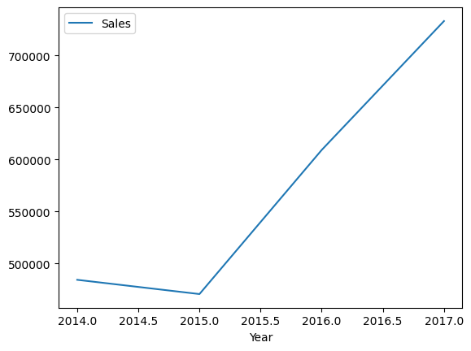

```python
yearly_trend.plot(x='Year', y='Sales', kind='line')
plt.show()
```

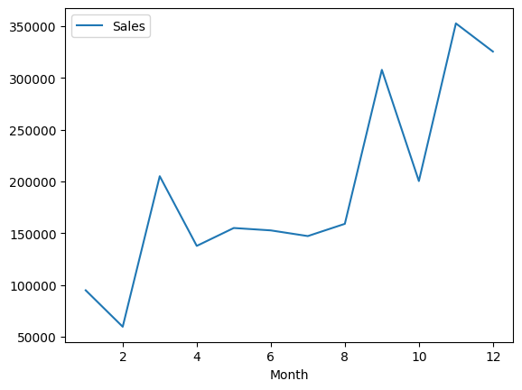

```python
monthly_trend.plot(x='Month', y='Sales', kind='line')
plt.show()
```

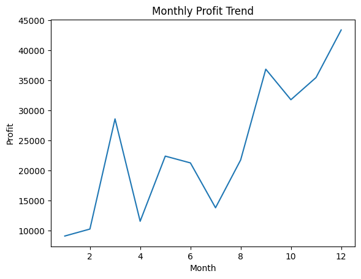

```python
plt.plot(monthly_trend['Month'], monthly_trend['Profit'])
plt.xlabel("Month")
plt.ylabel("Profit")
plt.title("Monthly Profit Trend")

plt.show()
```

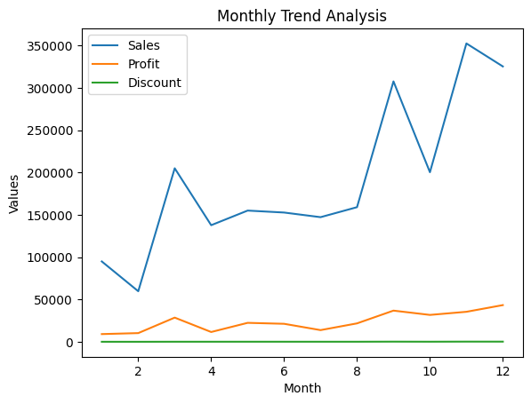

```python
import matplotlib.pyplot as plt

plt.figure()

plt.plot(monthly_trend['Month'], monthly_trend['Sales'], label='Sales')
plt.plot(monthly_trend['Month'], monthly_trend['Profit'], label='Profit')
plt.plot(monthly_trend['Month'], monthly_trend['Discount'], label='Discount')

plt.xlabel("Month")
plt.ylabel("Values")
plt.title("Monthly Trend Analysis")

plt.legend()
plt.show()
```

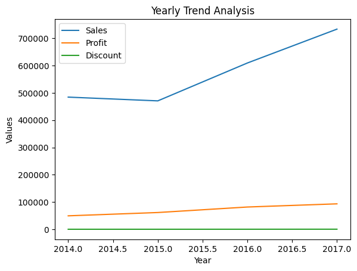

```python
plt.figure()

plt.plot(yearly_trend['Year'], yearly_trend['Sales'], label='Sales')
plt.plot(yearly_trend['Year'], yearly_trend['Profit'], label='Profit')
plt.plot(yearly_trend['Year'], yearly_trend['Discount'], label='Discount')

plt.xlabel("Year")
plt.ylabel("Values")
plt.title("Yearly Trend Analysis")

plt.legend()
plt.show()
```

12. What are the peak sales periods (months/quarters), and how do they vary by region?

```python
df['Quarter'] = df['Order Date'].dt.quarter
```

```python
monthly_sales = df.groupby('Month')['Sales'].sum().reset_index()
monthly_sales.sort_values(by='Sales', ascending=False)
```

|  | Month | Sales |
| --- | --- | --- |
| 10 | 11 | 352461.0710 |
| 11 | 12 | 325293.5035 |
| 8 | 9 | 307649.9457 |
| 2 | 3 | 205005.4888 |
| 9 | 10 | 200322.9847 |
| 7 | 8 | 159044.0630 |
| 4 | 5 | 155028.8117 |
| 5 | 6 | 152718.6793 |
| 6 | 7 | 147238.0970 |
| 3 | 4 | 137762.1286 |
| 0 | 1 | 94924.8356 |
| 1 | 2 | 59751.2514 |

```python
quarter_sales = df.groupby('Quarter')['Sales'].sum().reset_index()
quarter_sales.sort_values(by='Sales', ascending=False)
```

|  | Quarter | Sales |
| --- | --- | --- |
| 3 | 4 | 878077.5592 |
| 2 | 3 | 613932.1057 |
| 1 | 2 | 445509.6196 |
| 0 | 1 | 359681.5758 |

```python
region_month = df.groupby(['Region', 'Month'])['Sales'].sum().reset_index()
print(region_month)
```

```
     Region  Month        Sales
0   Central      1   31683.2296
1   Central      2    8211.3104
2   Central      3   41216.2618
3   Central      4   26199.8706
4   Central      5   36005.2282
5   Central      6   32879.3948
6   Central      7   32113.5610
7   Central      8   25559.1830
8   Central      9   76833.4122
9   Central     10   53920.9312
10  Central     11   65025.9490
11  Central     12   71591.5590
12     East      1   15350.5390
13     East      2   14781.2520
```

[output cut: 34 more lines]

# Product Performance & Inventory Insights

13. Which sub-categories have the highest sales-to-quantity ratio (indicating high value per unit sold)?

```python
ratio_df = df.groupby('Sub-Category').agg({'Sales': 'sum', 'Quantity': 'sum'}).reset_index()
print(ratio_df)
ratio_df['Sales_per_Unit'] = ratio_df['Sales'] / ratio_df['Quantity']
```

```
   Sub-Category        Sales  Quantity
0   Accessories  167380.3180      2976
1    Appliances  107532.1610      1729
2           Art   27118.7920      3000
3       Binders  203412.7330      5974
4     Bookcases  114879.9963       868
5        Chairs  328449.1030      2356
6       Copiers  149528.0300       234
7     Envelopes   16476.4020       906
8     Fasteners    3024.2800       914
9   Furnishings   91705.1640      3563
10       Labels   12486.3120      1400
11     Machines  189238.6310       440
12        Paper   78479.2060      5178
13       Phones  330007.0540      3289
14      Storage  223843.6080      3158
15     Supplies   46673.5380       647
16       Tables  206965.5320      1241
```

```python
# Top high value products
top_value = ratio_df.sort_values(by='Sales_per_Unit', ascending=False)
print(top_value)
```

```
   Sub-Category        Sales  Quantity  Sales_per_Unit
6       Copiers  149528.0300       234      639.008675
11     Machines  189238.6310       440      430.087798
16       Tables  206965.5320      1241      166.773193
5        Chairs  328449.1030      2356      139.409636
4     Bookcases  114879.9963       868      132.350226
13       Phones  330007.0540      3289      100.336593
15     Supplies   46673.5380       647       72.138389
14      Storage  223843.6080      3158       70.881446
1    Appliances  107532.1610      1729       62.193268
0   Accessories  167380.3180      2976       56.243386
3       Binders  203412.7330      5974       34.049671
9   Furnishings   91705.1640      3563       25.738188
7     Envelopes   16476.4020       906       18.185874
12        Paper   78479.2060      5178       15.156278
2           Art   27118.7920      3000        9.039597
10       Labels   12486.3120      1400        8.918794
8     Fasteners    3024.2800       914        3.308840
```

```python
# Low value products
low_value = ratio_df.sort_values(by='Sales_per_Unit', ascending=True)
print(low_value)
```

```
   Sub-Category        Sales  Quantity  Sales_per_Unit
8     Fasteners    3024.2800       914        3.308840
10       Labels   12486.3120      1400        8.918794
2           Art   27118.7920      3000        9.039597
12        Paper   78479.2060      5178       15.156278
7     Envelopes   16476.4020       906       18.185874
9   Furnishings   91705.1640      3563       25.738188
3       Binders  203412.7330      5974       34.049671
0   Accessories  167380.3180      2976       56.243386
1    Appliances  107532.1610      1729       62.193268
14      Storage  223843.6080      3158       70.881446
15     Supplies   46673.5380       647       72.138389
13       Phones  330007.0540      3289      100.336593
4     Bookcases  114879.9963       868      132.350226
5        Chairs  328449.1030      2356      139.409636
16       Tables  206965.5320      1241      166.773193
11     Machines  189238.6310       440      430.087798
6       Copiers  149528.0300       234      639.008675
```

14. What are the most frequently ordered product combinations? (market basket analysis)

```python
market_basket = df.groupby('Order ID')['Product Name'].apply(lambda x: list(x)).reset_index()
print("\n14. Sample Product Combinations")
print(market_basket.head(10))
```

```
14. Sample Product Combinations
         Order ID                                       Product Name
0  CA-2014-100006                                [AT&T EL51110 DECT]
1  CA-2014-100090  [Hon 2111 Invitation Series Corner Table, Wils...
2  CA-2014-100293                                       [Xerox 1887]
3  CA-2014-100328  [Pressboard Covers with Storage Hooks, 9 1/2" ...
4  CA-2014-100363  [Binder Clips by OIC, Things To Do Today Spira...
5  CA-2014-100391                     [Strathmore Photo Frame Cards]
6  CA-2014-100678  [Prang Dustless Chalk Sticks, DMI Arturo Colle...
7  CA-2014-100706  [Case Logic 2.4GHz Wireless Keyboard, Ultra Do...
8  CA-2014-100762  [Hunt PowerHouse Electric Pencil Sharpener, Bl...
9  CA-2014-100860  [Smead Alpha-Z Color-Coded Name Labels First L...
```